# Practica 3: Algoritmos geneticos

Practica realizada por Tomas Higuera Viso y Alejandro Naranjo Jimenez

## Estructura del clasificador

En esta practica se nos pide desarrollar un clasificador que funciona con un algoritmo genetico. El algoritmo lo desarrollaremos utilizando el algoritmo de Pittsburgh. En este algoritmo cada cromosoma tiene un numero aleatorio de reglas. Cada una de estas reglas contiene los genes de cada atributo.

La estructura del clasificador implementada es la siguiente:

[ClasificadorAG] -- lista de -->[Cromosoma] -- lista de -->[Regla] ==> (Regla binaria o Rega enteros)

#### A) Generacion de la poblacion incial con especial indicacion del numero de reglas por individuo consideradas:

La poblacion incial se crea de manera aleatoria siempre dentro de los intervalos especificados para cada atributo. Las reglas inicales tienen una alta probabilidad de que los genes valgan 0, a pesar de ser creadas de manera aleatoria. De esta manera nuestro algoritmo empieza descubriendo los atributos menos relevantes y creara reglas con valor 0 en ellos.

El numero de reglas incial es aleatorio pero con un maximo pasado como parametro.

#### B) Mecanismo de cruce implementado:

El mecanismo implementado es el de cruce en un punto, es decir, se cruzan las reglas entre dos cromosomas, el punto de cruce es siempre aleatorio.

#### C) Mecanismo de mutacion implementado:

Mutamos un porcentaje aleatorio de individuos. Cada individuo elige de manera aleatoria una de las reglas y la muta. El la mutacion, dada una probabilidad, se muta cada gen, es decir se inserta de nuevo de manera aleatoria.

## Detalles del codigo

### ClasificadorAG

El clasificador tiene 2 funciones principales:

```
- entrenamiento(self, datostrain, diccionario): Usa el algoritmo genetico para evolucionar una poblacion hasta un numero maximo de generaciones o hasta un fitness determinado.

- clasifica(self, datostest, diccionario): Una vez se ha entrenado se escoge el mejor individuo y se clasifican los datostest con este.
```

Una vez clasificado y obtenido el array de predicciones hayamos las tasas de error haciendo uso de la funcion error(self, datos, pred).

La evolucion de la poblacion que se realiza en el entrenamiento hace uso de 3 funciones:

```
- seleccion_progenitores(self): Hace uso de la poblacion del clasificador para devolver otra poblacion del mismo tamaño proporcional al fitness.

- cruce(self, poblacion): Utilizando la poblacion recibida como parametros, con una proporcion pc, se escoge un numero par de individuos de manera aleatoria y de dos en dos cruzamos e insertamos vastagos en la nueva poblacion.

- mutacion(self, poblacion): Igual que en el cruce, cogemos n individuos y los mutamos.
```

### Cromosoma

Los individuos de la poblacion son cromosomas que tienen un fitness y una lista aleatoria de reglas.

```
- predicciones(self, datos): Cuando una regla se cumple se incluye su clase en la votacion, sino se cumple no.

-  calculate_fit(self, datos): Usa la funcion anterior y compara lo que predice el cromosoma con la clase de la familia. El fitness es el porcentaje de aciertos respecto a los errores.
```

Ademas, tambien tiene las funciones de cruce y de mutacion:

```
- cruce(self, progenitor_2): Elige un punto aleatorio del cromosoma y se realiza el cruce. Devuelve los dos vastagos.

- mutacion(self, pmbit, n_intervalos): De forma aleatoria selecciona una regla aleatoria y la muta.
```

### Regla

Cada gen almacena los intervalos que almacena para un atributo. Existen dos tipos de reglas, las binarias y las enteras, la unica diferencia entre estas es la forma de representar el gen.

En las reglas de enteros cada gen contiene el numero del intervalo que acepta a 0.

En las reglas binarias, cada gen contiene una lista de 0s y 1s para indicar si se acepta un intervalo o no.

```
- seCumple(self, fila): Recibe una fila de datos transformada a regla y compara cada gen.

- mutacion(self, pmbit, n_intervalos): Se recorre cada gen y con una probabilidad pmbit el gen escogido se rellena aleatoriamente.
```

### Instrucciones del calsificador

Hemos creado una funcion main para ejecutar el clasificador dentro del fichero ClasificadorAG.py. Esta funcion recibe como parametros el fichero de datos sobre el que se ejecutara el algoritmo, asi como el numero maximo de individuos en cada poblacion y el numero maximo de generaciones que se crearan.

Los diferentes parametros del clasificador son los siguientes:

#### ClasificadorAlgoritmosGeneticos(self,dataset=None, esBinaria = False, npoblacion=10,max_reglas=40,c_parada=97, max_g = 100,pc=85,pm=10,pmbit=5,pe=2,test=None)

Parametros:

```
- dataset: El conjunto de datos.
- esBinaria: El tipo de regla a utilizar.
- nPoblacion: Poblacion del algoritmo genetico.
- max_reglas: El numero maximo de reglas posibles.
- c_parada: El valor maximo de fitness como condicion para parar la  creacion de generaciones.
- max_g: El numero maximo de generaciones a crear.
- pc: La probabilidad de cruce.
- pm: La probabilidad de mutacion.
- pmbit: La probabilidad de mutar un gen usado en reglas.
- pe: La proporcion de individuos que se mantendran de una generacion anterior.
- test: El nombre del archivo donde insertar los datos para realizar plot.
```

En la ejecucion hemos utilizado como estrategia de particionado la validacion simple, con una solo particion. Para cambiar el tipo de particion tan solo tendremos que cambiar dentro de la funcion main el tipo de particion haciendo uso de las funciones de EstrategiaParticionado.py.

### Ejecuciones

Para la ejecucion del algoritmo hemos utilizado el modelo generacional para realizar el elitismo en el que cada individuo vive una unica generacion.

A continuacion moostraremos los resultados de cada generacion al ir cambiando de generacion y finalmente mostraremos unas conclusiones de los resultados en forma de grafica y de tabla.

```python
%matplotlib inline
import ClasificadorAG
from plot_test import *
from IPython.display import *
```

### Tic-tac-toe (100,100)

Poblacion de tamaño 100.

Maximo de generaciones 100.

```python
ClasificadorAG.main('tic-tac-toe.data', 100, 100, 'tic-tac-toe-p100-g100.test')
```

```
Empezamos...
Generacion:  1
Fitness mejor individuo:  0.6234309623430963
Fitness medio:  0.5049372384937255
Generacion:  2
Fitness mejor individuo:  0.6234309623430963
Fitness medio:  0.4703765690376581
Generacion:  3
Fitness mejor individuo:  0.6234309623430963
Fitness medio:  0.5296234309623441
Generacion:  4
Fitness mejor individuo:  0.6234309623430963
Fitness medio:  0.5641841004184102
Generacion:  5
Fitness mejor individuo:  0.6234309623430963
Fitness medio:  0.5007949790794988
Generacion:  6
Fitness mejor individuo:  0.6234309623430963
Fitness medio:  0.5617154811715483
Generacion:  7
Fitness mejor individuo:  0.6234309623430963
Fitness medio:  0.4884518828451895
Generacion:  8
Fitness mejor individuo:  0.6234309623430963
Fitness medio:  0.5518410041841009
Generacion:  9
Fitness mejor individuo:  0.6234309623430963
Fitness medio:  0.4975313807531397
Generacion:  10
Fitness mejor individuo:  0.6234309623430963
Fitness medio:  0.5789958158995814
Generacion:  11
Fitness mejor individuo:  0.6234309623430963
Fitness medio:  0.5715899581589958
Generacion:  12
Fitness mejor individuo:  0.6234309623430963
Fitness medio:  0.5123430962343111
Generacion:  13
Fitness mejor individuo:  0.6234309623430963
Fitness medio:  0.6160251046025094
```

[output cut: 248 more lines]

```
Fitness medio:  0.6234309623430949
Generacion:  97
Fitness mejor individuo:  0.6234309623430963
Fitness medio:  0.6234309623430949
Generacion:  98
Fitness mejor individuo:  0.6234309623430963
Fitness medio:  0.6234309623430949
Generacion:  99
Fitness mejor individuo:  0.6234309623430963
Fitness medio:  0.6234309623430949
Generacion:  100
Fitness mejor individuo:  0.6234309623430963
Fitness medio:  0.6234309623430949
Tasa de error:  [0.33657858136300417]
Tasa de acierto:  0.6634214186369958
```

### Tic-tac-toe(100,300)

Poblacion de tamaño 100.

Maximo de generaciones 300.

```python
ClasificadorAG.main('tic-tac-toe.data', 100, 300, 'tic-tac-toe-p100-g300.test')
```

```
Empezamos...
Generacion:  1
Fitness mejor individuo:  0.6276150627615062
Fitness medio:  0.4872384937238493
Generacion:  2
Fitness mejor individuo:  0.6276150627615062
Fitness medio:  0.5396652719665272
Generacion:  3
Fitness mejor individuo:  0.6276150627615062
Fitness medio:  0.49489539748953976
Generacion:  4
Fitness mejor individuo:  0.6276150627615062
Fitness medio:  0.5740167364016738
Generacion:  5
Fitness mejor individuo:  0.6276150627615062
Fitness medio:  0.6046443514644354
Generacion:  6
Fitness mejor individuo:  0.6276150627615062
Fitness medio:  0.596987447698745
Generacion:  7
Fitness mejor individuo:  0.6276150627615062
Fitness medio:  0.5689121338912135
Generacion:  8
Fitness mejor individuo:  0.6276150627615062
Fitness medio:  0.6046443514644354
Generacion:  9
Fitness mejor individuo:  0.6276150627615062
Fitness medio:  0.5816736401673642
Generacion:  10
Fitness mejor individuo:  0.6276150627615062
Fitness medio:  0.5867782426778245
Generacion:  11
Fitness mejor individuo:  0.6276150627615062
Fitness medio:  0.5740167364016738
Generacion:  12
Fitness mejor individuo:  0.6276150627615062
Fitness medio:  0.6071966527196655
Generacion:  13
Fitness mejor individuo:  0.6276150627615062
Fitness medio:  0.5357322175732218
```

[output cut: 848 more lines]

```
Fitness medio:  0.5460251046025107
Generacion:  297
Fitness mejor individuo:  0.6276150627615062
Fitness medio:  0.564853556485356
Generacion:  298
Fitness mejor individuo:  0.6276150627615062
Fitness medio:  0.4267782426778245
Generacion:  299
Fitness mejor individuo:  0.6276150627615062
Fitness medio:  0.37029288702928886
Generacion:  300
Fitness mejor individuo:  0.6276150627615062
Fitness medio:  0.6276150627615066
Tasa de error:  [0.3379694019471488]
Tasa de acierto:  0.6620305980528511
```

### Tic-tac-toe(200,100)

Poblacion de tamaño 200.

Maximo de generaciones 100.

```python
ClasificadorAG.main('tic-tac-toe.data', 200, 100, 'tic-tac-toe-p200-g100.test')
```

```
Empezamos...
Generacion:  1
Fitness mejor individuo:  0.6736401673640168
Fitness medio:  0.5020502092050233
Generacion:  2
Fitness mejor individuo:  0.6736401673640168
Fitness medio:  0.5225732217573242
Generacion:  3
Fitness mejor individuo:  0.6736401673640168
Fitness medio:  0.5121548117154835
Generacion:  4
Fitness mejor individuo:  0.6736401673640168
Fitness medio:  0.5711924686192479
Generacion:  5
Fitness mejor individuo:  0.6736401673640168
Fitness medio:  0.5642468619246874
Generacion:  6
Fitness mejor individuo:  0.6736401673640168
Fitness medio:  0.5766108786610887
Generacion:  7
Fitness mejor individuo:  0.6736401673640168
Fitness medio:  0.4791631799163202
Generacion:  8
Fitness mejor individuo:  0.6736401673640168
Fitness medio:  0.5561297071129709
Generacion:  9
Fitness mejor individuo:  0.6736401673640168
Fitness medio:  0.5798744769874485
Generacion:  10
Fitness mejor individuo:  0.6736401673640168
Fitness medio:  0.6357531380753134
Generacion:  11
Fitness mejor individuo:  0.6736401673640168
Fitness medio:  0.6580125523012539
Generacion:  12
Fitness mejor individuo:  0.6736401673640168
Fitness medio:  0.6701673640167358
Generacion:  13
Fitness mejor individuo:  0.6736401673640168
Fitness medio:  0.5503556485355664
```

[output cut: 248 more lines]

```
Fitness medio:  0.6736401673640163
Generacion:  97
Fitness mejor individuo:  0.6736401673640168
Fitness medio:  0.49652719665272227
Generacion:  98
Fitness mejor individuo:  0.6736401673640168
Fitness medio:  0.6736401673640163
Generacion:  99
Fitness mejor individuo:  0.6736401673640168
Fitness medio:  0.6406485355648531
Generacion:  100
Fitness mejor individuo:  0.6736401673640168
Fitness medio:  0.6736401673640163
Tasa de error:  [0.3532684283727399]
Tasa de acierto:  0.6467315716272601
```

### Tic-tac-toe(200,300)

Poblacion de tamaño 200.

Maximo de generaciones 300.

```python
ClasificadorAG.main('tic-tac-toe.data', 200, 300, 'tic-tac-toe-p200-g300.test')
```

```
Empezamos...
Generacion:  1
Fitness mejor individuo:  0.6778242677824268
Fitness medio:  0.5056694560669457
Generacion:  2
Fitness mejor individuo:  0.6778242677824268
Fitness medio:  0.5177824267782427
Generacion:  3
Fitness mejor individuo:  0.6778242677824268
Fitness medio:  0.5197280334728034
Generacion:  4
Fitness mejor individuo:  0.6778242677824268
Fitness medio:  0.5609623430962344
Generacion:  5
Fitness mejor individuo:  0.6778242677824268
Fitness medio:  0.5657949790794979
Generacion:  6
Fitness mejor individuo:  0.6778242677824268
Fitness medio:  0.539121338912134
Generacion:  7
Fitness mejor individuo:  0.6778242677824268
Fitness medio:  0.5960251046025105
Generacion:  8
Fitness mejor individuo:  0.6778242677824268
Fitness medio:  0.5853556485355649
Generacion:  9
Fitness mejor individuo:  0.6778242677824268
Fitness medio:  0.6511506276150627
Generacion:  10
Fitness mejor individuo:  0.6778242677824268
Fitness medio:  0.6351464435146443
Generacion:  11
Fitness mejor individuo:  0.6778242677824268
Fitness medio:  0.5746861924686193
Generacion:  12
Fitness mejor individuo:  0.6778242677824268
Fitness medio:  0.6369246861924686
Generacion:  13
Fitness mejor individuo:  0.6778242677824268
Fitness medio:  0.6707112970711298
```

[output cut: 848 more lines]

```
Fitness medio:  0.6778242677824268
Generacion:  297
Fitness mejor individuo:  0.6778242677824268
Fitness medio:  0.6778242677824268
Generacion:  298
Fitness mejor individuo:  0.6778242677824268
Fitness medio:  0.6235983263598326
Generacion:  299
Fitness mejor individuo:  0.6778242677824268
Fitness medio:  0.6778242677824268
Generacion:  300
Fitness mejor individuo:  0.6778242677824268
Fitness medio:  0.5795397489539749
Tasa de error:  [0.35465924895688455]
Tasa de acierto:  0.6453407510431155
```

### Ejemplo1(100,100)

Poblacion de tamaño 100.

Maximo de generaciones 100.

```python
ClasificadorAG.main('ejemplo1.data', 100, 100, 'ejemplo1-p100-g100.test')
```

```
Empezamos...
Generacion:  1
Fitness mejor individuo:  0.56
Fitness medio:  0.5014
Generacion:  2
Fitness mejor individuo:  0.56
Fitness medio:  0.5018
Generacion:  3
Fitness mejor individuo:  0.56
Fitness medio:  0.502
Generacion:  4
Fitness mejor individuo:  0.56
Fitness medio:  0.5005999999999999
Generacion:  5
Fitness mejor individuo:  0.56
Fitness medio:  0.5005999999999999
Generacion:  6
Fitness mejor individuo:  0.77
Fitness medio:  0.5174
Generacion:  7
Fitness mejor individuo:  0.77
Fitness medio:  0.5054
Generacion:  8
Fitness mejor individuo:  0.77
Fitness medio:  0.5011999999999999
Generacion:  9
Fitness mejor individuo:  0.77
Fitness medio:  0.5135000000000001
Generacion:  10
Fitness mejor individuo:  0.77
Fitness medio:  0.5065999999999999
Generacion:  11
Fitness mejor individuo:  0.77
Fitness medio:  0.5125999999999997
Generacion:  12
Fitness mejor individuo:  0.77
Fitness medio:  0.506
Generacion:  13
Fitness mejor individuo:  0.77
Fitness medio:  0.5054
```

[output cut: 248 more lines]

```
Fitness medio:  0.5217000000000005
Generacion:  97
Fitness mejor individuo:  0.77
Fitness medio:  0.6471999999999999
Generacion:  98
Fitness mejor individuo:  0.77
Fitness medio:  0.40460000000000096
Generacion:  99
Fitness mejor individuo:  0.77
Fitness medio:  0.5319999999999999
Generacion:  100
Fitness mejor individuo:  0.77
Fitness medio:  0.6167000000000002
Tasa de error:  [0.25666666666666665]
Tasa de acierto:  0.7433333333333334
```

### Ejemplo1(100,300)

Poblacion de tamaño 100.

Maximo de generaciones 300.

```python
ClasificadorAG.main('ejemplo1.data', 100, 300, 'ejemplo1-p100-g300.test')
```

```
Empezamos...
Generacion:  1
Fitness mejor individuo:  0.78
Fitness medio:  0.5044999999999987
Generacion:  2
Fitness mejor individuo:  0.78
Fitness medio:  0.5127999999999986
Generacion:  3
Fitness mejor individuo:  0.78
Fitness medio:  0.5107999999999986
Generacion:  4
Fitness mejor individuo:  0.78
Fitness medio:  0.5132999999999993
Generacion:  5
Fitness mejor individuo:  0.78
Fitness medio:  0.5083999999999985
Generacion:  6
Fitness mejor individuo:  0.78
Fitness medio:  0.5167999999999996
Generacion:  7
Fitness mejor individuo:  0.78
Fitness medio:  0.5083999999999985
Generacion:  8
Fitness mejor individuo:  0.78
Fitness medio:  0.4981999999999988
Generacion:  9
Fitness mejor individuo:  0.78
Fitness medio:  0.5020999999999988
Generacion:  10
Fitness mejor individuo:  0.78
Fitness medio:  0.5080999999999986
Generacion:  11
Fitness mejor individuo:  0.78
Fitness medio:  0.5575999999999991
Generacion:  12
Fitness mejor individuo:  0.78
Fitness medio:  0.5246999999999995
Generacion:  13
Fitness mejor individuo:  0.78
Fitness medio:  0.448799999999999
```

[output cut: 848 more lines]

```
Fitness medio:  0.6266000000000013
Generacion:  297
Fitness mejor individuo:  0.78
Fitness medio:  0.7048000000000006
Generacion:  298
Fitness mejor individuo:  0.78
Fitness medio:  0.7518000000000005
Generacion:  299
Fitness mejor individuo:  0.78
Fitness medio:  0.7674000000000007
Generacion:  300
Fitness mejor individuo:  0.78
Fitness medio:  0.6825000000000009
Tasa de error:  [0.26]
Tasa de acierto:  0.74
```

### Ejemplo1(200,100)

Poblacion de tamaño 200.

Maximo de generaciones 100.

```python
ClasificadorAG.main('ejemplo1.data', 200, 100, 'ejemplo1-p200-g100.test')
```

```
Empezamos...
Generacion:  1
Fitness mejor individuo:  0.72
Fitness medio:  0.49360000000000276
Generacion:  2
Fitness mejor individuo:  0.72
Fitness medio:  0.503550000000003
Generacion:  3
Fitness mejor individuo:  0.72
Fitness medio:  0.500050000000003
Generacion:  4
Fitness mejor individuo:  0.72
Fitness medio:  0.5158000000000024
Generacion:  5
Fitness mejor individuo:  0.72
Fitness medio:  0.5047500000000014
Generacion:  6
Fitness mejor individuo:  0.72
Fitness medio:  0.5077500000000028
Generacion:  7
Fitness mejor individuo:  0.79
Fitness medio:  0.5619499999999998
Generacion:  8
Fitness mejor individuo:  0.79
Fitness medio:  0.5364000000000005
Generacion:  9
Fitness mejor individuo:  0.79
Fitness medio:  0.532300000000001
Generacion:  10
Fitness mejor individuo:  0.79
Fitness medio:  0.5339500000000018
Generacion:  11
Fitness mejor individuo:  0.79
Fitness medio:  0.5490999999999994
Generacion:  12
Fitness mejor individuo:  0.79
Fitness medio:  0.5330000000000009
Generacion:  13
Fitness mejor individuo:  0.79
Fitness medio:  0.5207500000000024
```

[output cut: 248 more lines]

```
Fitness medio:  0.683149999999999
Generacion:  97
Fitness mejor individuo:  0.79
Fitness medio:  0.49525000000000013
Generacion:  98
Fitness mejor individuo:  0.79
Fitness medio:  0.5433000000000032
Generacion:  99
Fitness mejor individuo:  0.79
Fitness medio:  0.5932999999999986
Generacion:  100
Fitness mejor individuo:  0.79
Fitness medio:  0.5128999999999999
Tasa de error:  [0.2633333333333333]
Tasa de acierto:  0.7366666666666667
```

### Ejemplo1(200,300)

Poblacion de tamaño 200.

Maximo de generaciones 300.

```python
ClasificadorAG.main('ejemplo1.data', 200, 300, 'ejemplo1-p200-g300.test')
```

```
Empezamos...
Generacion:  1
Fitness mejor individuo:  0.8
Fitness medio:  0.5044000000000032
Generacion:  2
Fitness mejor individuo:  0.8
Fitness medio:  0.512800000000003
Generacion:  3
Fitness mejor individuo:  0.8
Fitness medio:  0.49020000000000286
Generacion:  4
Fitness mejor individuo:  0.8
Fitness medio:  0.5424000000000013
Generacion:  5
Fitness mejor individuo:  0.8
Fitness medio:  0.5498000000000003
Generacion:  6
Fitness mejor individuo:  0.8
Fitness medio:  0.5566000000000006
Generacion:  7
Fitness mejor individuo:  0.8
Fitness medio:  0.5646
Generacion:  8
Fitness mejor individuo:  0.8
Fitness medio:  0.5250000000000015
Generacion:  9
Fitness mejor individuo:  0.8
Fitness medio:  0.5170000000000026
Generacion:  10
Fitness mejor individuo:  0.8
Fitness medio:  0.5799999999999997
Generacion:  11
Fitness mejor individuo:  0.8
Fitness medio:  0.5777999999999988
Generacion:  12
Fitness mejor individuo:  0.8
Fitness medio:  0.5664
Generacion:  13
Fitness mejor individuo:  0.8
Fitness medio:  0.5272000000000019
```

[output cut: 848 more lines]

```
Fitness medio:  0.7139999999999966
Generacion:  297
Fitness mejor individuo:  0.8
Fitness medio:  0.6869999999999962
Generacion:  298
Fitness mejor individuo:  0.8
Fitness medio:  0.746999999999997
Generacion:  299
Fitness mejor individuo:  0.8
Fitness medio:  0.7489999999999971
Generacion:  300
Fitness mejor individuo:  0.8
Fitness medio:  0.7179999999999968
Tasa de error:  [0.26666666666666666]
Tasa de acierto:  0.7333333333333334
```

### Ejemplo2(100,100)

Poblacion de tamaño 100.

Maximo de generaciones 100.

```python
ClasificadorAG.main('ejemplo2.data', 100, 100, 'ejemplo2-p100-g100.test')
```

```
Empezamos...
Generacion:  1
Fitness mejor individuo:  1.0
Fitness medio:  0.5200999999999998
Tasa de error:  [0.0]
Tasa de acierto:  1.0
```

### Ejemplo2(100,300)

Poblacion de tamaño 100.

Maximo de generaciones 300.

```python
ClasificadorAG.main('ejemplo2.data', 100, 300, 'ejemplo2-p100-g300.test')
```

```
Empezamos...
Generacion:  1
Fitness mejor individuo:  1.0
Fitness medio:  0.5123000000000011
Tasa de error:  [0.0]
Tasa de acierto:  1.0
```

### Ejemplo2(200,100)

Poblacion de tamaño 200.

Maximo de generaciones 100.

```python
ClasificadorAG.main('ejemplo2.data', 200, 100, 'ejemplo2-p200-g100.test')
```

```
Empezamos...
Generacion:  1
Fitness mejor individuo:  1.0
Fitness medio:  0.5278999999999999
Tasa de error:  [0.0]
Tasa de acierto:  1.0
```

### Ejemplo2(200,300)

Poblacion de tamaño 200.

Maximo de generaciones 300.

```python
ClasificadorAG.main('ejemplo2.data', 200, 300, 'ejemplo2-p200-g300.test')
```

```
Empezamos...
Generacion:  1
Fitness mejor individuo:  1.0
Fitness medio:  0.5118999999999982
Tasa de error:  [0.0]
Tasa de acierto:  1.0
```

### Conclusiones

#### Tic-tac-toe.data

```python
tic_tac_toe_exe = "<table><tr><th>Resultados</th><th>100p 100g</th><th>100p 300g</th><th>200p 100g</th><th>200p 300g</th></tr>"
tic_tac_toe_exe += "<tr><td>Best Fitness</td><td>0.6234</td><td>0.6276</td><td>0.6736</td><td>0.6778</td>"
tic_tac_toe_exe += "<tr><td>Acierto</td><td>0.6634</td><td>0.6620</td><td>0.6467</td><td>0.6453</td></tr></table>"
display(HTML(tic_tac_toe_exe))
```

| Resultados | 100p 100g | 100p 300g | 200p 100g | 200p 300g |
| --- | --- | --- | --- | --- |
| Best Fitness | 0.6234 | 0.6276 | 0.6736 | 0.6778 |
| Acierto | 0.6634 | 0.6620 | 0.6467 | 0.6453 |

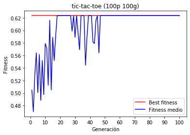

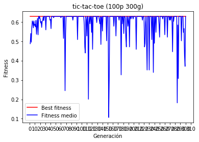

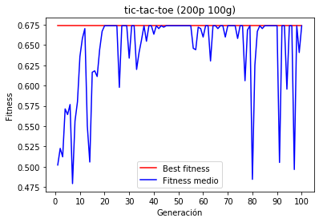

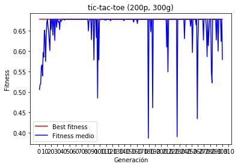

```python
make_plot("test/tic-tac-toe-p100-g100.test","tic-tac-toe (100p 100g)")
make_plot("test/tic-tac-toe-p100-g300.test","tic-tac-toe (100p 300g)")
make_plot("test/tic-tac-toe-p200-g100.test","tic-tac-toe (200p 100g)")
make_plot("test/tic-tac-toe-p200-g300.test","tic-tac-toe (200p, 300g)")
```

Debido a la naturaleza del algortimo, los resultados pueden en cada ejecucion.

La tasa de acierto obtneida es de alrededor del 65% en todos los casos, al igual que el valor del fitness del mejor individuo es tambien de alrededor del 65% en todas las ejecuciones.

#### Ejemplo1.data

```python
ejemplo1_exe = "<table><tr><th>Resultados</th><th>100p 100g</th><th>100p 300g</th><th>200p 100g</th><th>200p 300g</th></tr>"
ejemplo1_exe += "<tr><td>Best Fitness</td><td>0.77</td><td>0.78</td><td>0.79</td><td>0.8</td>"
ejemplo1_exe += "<tr><td>Acierto</td><td>0.7433</td><td>0.74</td><td>0.7367</td><td>0.7333</td></tr></table>"
display(HTML(ejemplo1_exe))
```

| Resultados | 100p 100g | 100p 300g | 200p 100g | 200p 300g |
| --- | --- | --- | --- | --- |
| Best Fitness | 0.77 | 0.78 | 0.79 | 0.8 |
| Acierto | 0.7433 | 0.74 | 0.7367 | 0.7333 |

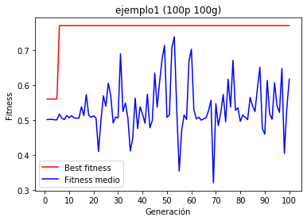

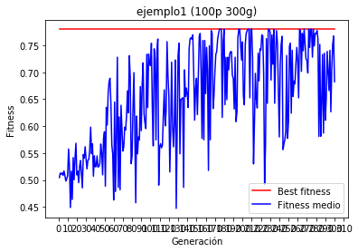

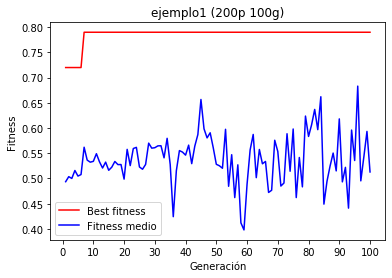

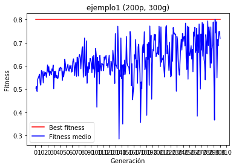

```python
make_plot("test/ejemplo1-p100-g100.test","ejemplo1 (100p 100g)")
make_plot("test/ejemplo1-p100-g300.test","ejemplo1 (100p 300g)")
make_plot("test/ejemplo1-p200-g100.test","ejemplo1 (200p 100g)")
make_plot("test/ejemplo1-p200-g300.test","ejemplo1 (200p, 300g)")
```

Al igual que nos ocurria en el conjunto de datos anterior, los resultados obtenidos son muy similares. La tasa de acierto se mantiene en el 74%. El mejor fitness obtenido despues de todas las ejecuciones es del 80%.

#### Ejemplo2.data

```python
ejemplo2_exe = "<table><tr><th>Resultados</th><th>100p 100g</th><th>100p 300g</th><th>200p 100g</th><th>200p 300g</th></tr>"
ejemplo2_exe += "<tr><td>Best Fitness</td><td>1</td><td>1</td><td>1</td><td>1</td>"
ejemplo2_exe += "<tr><td>Acierto</td><td>1</td><td>1</td><td>1</td><td>1</td></tr></table>"
display(HTML(ejemplo2_exe))
```

| Resultados | 100p 100g | 100p 300g | 200p 100g | 200p 300g |
| --- | --- | --- | --- | --- |
| Best Fitness | 1 | 1 | 1 | 1 |
| Acierto | 1 | 1 | 1 | 1 |

[figure not shown]

[figure not shown]

[figure not shown]

[figure not shown]

```python
make_plot("test/ejemplo2-p100-g100.test","ejemplo2 (100p 100g)")
make_plot("test/ejemplo2-p100-g300.test","ejemplo2 (100p 300g)")
make_plot("test/ejemplo2-p200-g100.test","ejemplo2 (200p 100g)")
make_plot("test/ejemplo2-p200-g300.test","ejemplo2 (200p, 300g)")
```

En este caso, las graficas de resultados no son de utilidad, ya que hemos obtenido un fitness de 1 al igual que una tasa de aciertos del 100% en todas las ejecuciones. Ademas, los fitness obtenidos se han producido en la primera generacion.